# Genome-wide association studies

Edoardo “Dado” Marcora

## Introduction to genome-wide association studies (GWAS)

### PLINK files

- https://www.cog-genomics.org/plink2/

#### Genotypes MAP file

```r
head(read.table("genotypes.map", header = FALSE, as.is = TRUE))
```

```
##   V1         V2 V3     V4
## 1 12  rs7954886  0 180185
## 2 12  rs4079417  0 180472
## 3 12 rs11063263  0 191619
## 4 12 rs10774263  0 192220
## 5 12 rs11614957  0 195309
## 6 12 rs12425974  0 196575
```

Rows are SNPs

- V1 = Chromosome code
- V2 = Variant ID
- V3 = Position in cM
- V4 = Position in bp

#### Genotypes PED file

```r
head(read.table(pipe('cut -d " " -f 1-10 genotypes.ped'), header = FALSE, as.is = TRUE))
```

```
##        V1      V2 V3 V4 V5 V6 V7 V8 V9 V10
## 1 HG00096 HG00096  0  0  1 -9  T  T  C   C
## 2 HG00097 HG00097  0  0  2 -9  T  T  C   C
## 3 HG00099 HG00099  0  0  2 -9  T  T  C   C
## 4 HG00100 HG00100  0  0  2 -9  T  T  C   C
## 5 HG00101 HG00101  0  0  1 -9  T  T  C   C
## 6 HG00102 HG00102  0  0  2 -9  T  T  C   C
```

Rows are samples

- V1 = Family ID (FID)
- V2 = Within-family/Individual ID (IID)
- V3 = Mother ID (0 if not available)
- V4 = Father ID (0 if not available)
- V5 = Sex code (1 = male, 2 = female, 0 = unknown)
- V6 = Phenotype code (1 = affected, 2 = unaffected, -9 if not applicable or not available)
- V7-8 = Genotype of first SNP
- V9-10 = Genotype of second SNP
- …

#### Phenotypes (and covariates) TXT file

```r
phenotypes = read.table("phenotypes.txt", header = TRUE, as.is = TRUE)
str(phenotypes)
```

```
## 'data.frame':    450 obs. of  18 variables:
##  $ FID       : chr  "HG00096" "HG00097" "HG00099" "HG00100" ...
##  $ IID       : chr  "HG00096" "HG00097" "HG00099" "HG00100" ...
##  $ Z         : num  -0.237 -0.129 -0.56 0.197 0.16 ...
##  $ Y1        : num  1.853 1.37 2.106 3.115 0.349 ...
##  $ Y2        : num  0.626 0.256 -0.111 -0.903 -2.36 ...
##  $ Gender    : int  1 2 2 2 1 2 1 1 2 1 ...
##  $ Population: chr  "GBR" "GBR" "GBR" "GBR" ...
##  $ Ancestry  : chr  "EUR" "EUR" "EUR" "EUR" ...
##  $ PC1       : num  -0.0521 -0.0534 -0.054 -0.0546 -0.0533 -0.0533 -0.0538 -0.0539 -0.0528 -0.0555 ...
##  $ PC2       : num  -0.0848 -0.0909 -0.0916 -0.0984 -0.1052 ...
##  $ PC3       : num  -0.0769 -0.0023 -0.0107 -0.0177 -0.0592 0.0357 0.07 0.0183 -0.0176 -0.0102 ...
##  $ PC4       : num  0.0012 -0.0414 0.1079 -0.0107 0.0187 ...
##  $ PC5       : num  0.0263 0.0821 -0.001 0.0888 0.035 ...
##  $ PC6       : num  0.0113 0.0888 -0.0483 0.0216 -0.0403 -0.0715 -0.0491 -0.0566 -0.0283 0.0346 ...
##  $ PC7       : num  0.0571 0.1008 -0.0465 -0.1506 0.0263 ...
##  $ PC8       : num  -0.0241 -0.0089 -0.0853 -0.0589 -0.0485 ...
##  $ PC9       : num  -0.044 -0.1311 -0.0112 0.0593 0.0202 ...
##  $ PC10      : num  -0.0741 -0.0259 -0.081 0.0004 0.0643 -0.0408 -0.0218 -0.0218 -0.0323 0.0821 ...
```

#### Convert genotypes files to binary format (BED, BIM and FAM files)

```bash
plink2 --file genotypes --make-bed --out genotypes
```

## GWAS data cleaning

- http://www.ncbi.nlm.nih.gov/pubmed/20718045
- http://www.ncbi.nlm.nih.gov/pubmed/23652425
- http://www.ncbi.nlm.nih.gov/pubmed/21085122
- http://www.bioconductor.org/packages/release/bioc/vignettes/GWASTools/inst/doc/DataCleaning.pdf
- http://www.h3abionet.org/component/attachments/download/285
- SNP exclusion
  - Exclude SNPs with a high missing rate
  - Exclude SNPs with a low minor allele frequency
  - Exclude SNPs that depart from [Hardy-Weinberg equilibrium](https://en.wikipedia.org/wiki/Hardy%E2%80%93Weinberg_principle)
- Sample exclusion
  - Exclude samples with a high missing rate
  - Exclude samples with sex discordance (e.g., due to sample swap or contamination):
  - Exclude duplicate samples and first-degree relatives
  - Exclude samples with high heterozigosity (e.g., due to sample contamination or population outliers)
  - Exclude population outliers or samples with ancestry discordance

### Exclude SNPs with a high missing rate

```bash
plink2 --bfile genotypes --geno 0.05 --make-bed --out genotypes.01
```

### Exclude SNPs with a low minor allele frequency

```bash
plink2 --bfile genotypes.01 --maf 0.01 --make-bed --out genotypes.02
```

### Exclude SNPs that depart from Hardy-Weinberg equilibrium

Calculate statistics for HWE fit:

```bash
plink2 --bfile genotypes.02 --hardy --out genotypes.03
```

```r
genotypes.03.hwe = read.table("genotypes.03.hwe", header = TRUE, check.names = FALSE, as.is = TRUE)
head(genotypes.03.hwe)
```

```
##   CHR        SNP    TEST A1 A2        GENO  O(HET)  E(HET)         P
## 1  12  rs7954886 ALL(NP)  C  T   12/85/352 0.18930 0.21330 2.442e-02
## 2  12  rs4079417 ALL(NP)  A  C    0/14/435 0.03118 0.03069 1.000e+00
## 3  12 rs11063263 ALL(NP)  G  A 114/211/124 0.46990 0.49980 2.196e-01
## 4  12 rs10774263 ALL(NP)  G  A 110/207/132 0.46100 0.49880 1.084e-01
## 5  12 rs11614957 ALL(NP)  A  G  54/203/192 0.45210 0.45280 1.000e+00
## 6  12 rs12425974 ALL(NP)  C  G  68/145/236 0.32290 0.43000 1.991e-07
```

For each SNP:

- CHR = Chromosome code
- SNP = Variant ID
- TEST = Type of test (ALL|AFF|UNAFF|ALL(QT)|ALL(NP))
- A1 = Allele 1 (usually minor)
- A2 = Allele 2 (usually major)
- GENO = genotypes count (A1 hom/het/A2 hom)
- O(HET) = Observed heterozygote frequency
- E(HET) = Expected heterozygote frequency
- P = Hardy-Weinberg equilibrium exact test P-value

Generate and inspect the QQ-plot of observed vs expected (i.e., uniform under the null) P-values and decide which P-value threshold to use for SNP exclusion:

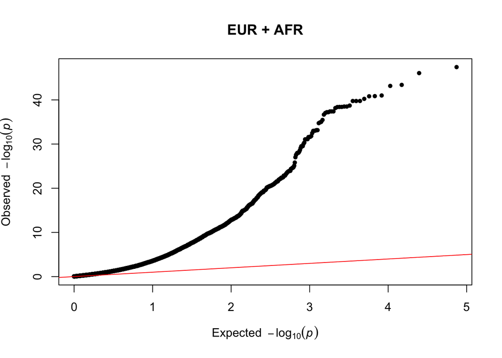

```r
qq(genotypes.03.hwe$P, main = "EUR + AFR")
```

The QQ-plot reveals a major departure from HWE which, in this case, is due to the fact that the sample dataset contains both EUR and AFR ancestry individuals.

Split the dataset into EUR and AFR ancestry subsets, re-calculate HWE stats for each subset separately and re-plot:

```bash
plink2 --bfile genotypes.02 --filter phenotypes.txt EUR --mfilter 6 --hardy --out genotypes.03.EUR
plink2 --bfile genotypes.02 --filter phenotypes.txt AFR --mfilter 6 --hardy --out genotypes.03.AFR
```

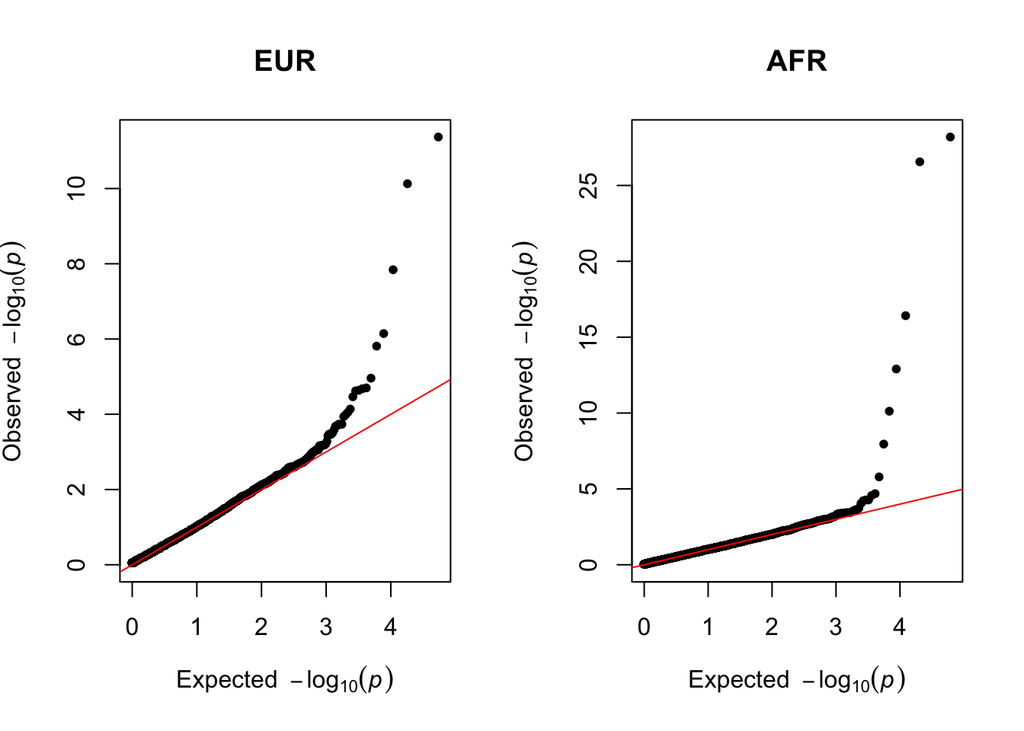

```r
par(mfrow = c(1,2))

genotypes.03.EUR.hwe = read.table("genotypes.03.EUR.hwe", header = TRUE, check.names = FALSE, as.is = TRUE)
qq(genotypes.03.EUR.hwe$P, main = "EUR")

genotypes.03.AFR.hwe = read.table("genotypes.03.AFR.hwe", header = TRUE, check.names = FALSE, as.is = TRUE)
qq(genotypes.03.AFR.hwe$P, main = "AFR")
```

```r
par(mfrow = c(1,1))
```

The QQ-plots reveal that SNPs with P-values ≤ 10e-5 depart from HWE. Use this P-value threshold for SNP exclusion in each subset separately and merge the two subsets:

```bash
plink2 --bfile genotypes.02 --filter phenotypes.txt EUR --mfilter 6 --hwe 0.00001 --make-bed --out genotypes.04.EUR
plink2 --bfile genotypes.02 --filter phenotypes.txt AFR --mfilter 6 --hwe 0.00001 --make-bed --out genotypes.04.AFR

plink2 --bfile genotypes.04.EUR --bmerge genotypes.04.AFR --make-bed --out genotypes.04
```

### Exclude samples with a high missing rate

```bash
plink2 --bfile genotypes.04 --mind 0.05 --make-bed --out genotypes.05
```

### Exclude samples with sex discordance

Calculate statistics to identify sex-discordant samples (e.g., due to sample swap or contamination) for sample exclusion:

```bash
plink2 --bfile genotypes.05 --check-sex --out genotypes.06
```

```r
genotypes.06.sexcheck = read.table("genotypes.06.sexcheck", header = TRUE, check.names = FALSE, as.is = TRUE)
head(genotypes.06.sexcheck)
```

```
##    FID     IID PEDSEX SNPSEX  STATUS   F
## 1 2367 NA19700      1      0 PROBLEM NaN
## 2 2367 NA19701      2      0 PROBLEM NaN
## 3 2368 NA19703      1      0 PROBLEM NaN
## 4 2368 NA19704      2      0 PROBLEM NaN
## 5 2369 NA19707      2      0 PROBLEM NaN
## 6 2371 NA19711      1      0 PROBLEM NaN
```

For each sample:

- FID = Family ID
- IID = Within-family/Individual ID
- PEDSEX = Sex code in input file
- SNPSEX = Imputed sex code (1 = male, 2 = female, 0 = unknown)
- STATUS = OK if PEDSEX and SNPSEX match and are nonzero, PROBLEM otherwise
- F = Inbreeding coefficient, considering only X chromosome
- YCOUNT = Number of nonmissing genotype calls on Y chromosome (optional)

$F = 1 - O/E$

O = Observed # of heterozygous SNPs on the X chromosome

E = Expected # of heterozygous SNPs on the X chromosome assuming HWE

Accounting for sampling noise, sample is male if F > 0.8 (theoretically it should be 1 because O = 0) and female if F < 0.2 (theoretically it should be 0 because 0 = 1).

```bash
plink2 --bfile genotypes.05 --make-bed --out genotypes.07
```

If sex discordant samples are identified, add `--remove samples_to_exclude.txt` to remove them.

### Exclude duplicate samples and first-degree relatives

Exclude duplicate samples and close relatives by finding pairs of samples with high (> 0.1) IBS/IBD PI_HAT values.

Calculate IBS/IBD statistics for each pair of samples and output them if PI_HAT > 0.05:

```bash
plink2 --bfile genotypes.07 --genome --min 0.05 --out genotypes.08
```

These calculations are NOT LD-sensitive and therefore is usually a good idea to perform some form of LD-based pruning before invoking them!

```r
genotypes.08.genome = read.table("genotypes.08.genome", header = TRUE, check.names = FALSE, as.is = TRUE)
head(genotypes.08.genome)
```

```
##   FID1    IID1 FID2    IID2 RT EZ     Z0     Z1     Z2 PI_HAT PHE      DST
## 1 2367 NA19700 2367 NA19701 OT  0 0.9427 0.0000 0.0573 0.0573  -1 0.764560
## 2 2367 NA19700 2368 NA19703 UN NA 0.9063 0.0522 0.0416 0.0676  -1 0.769049
## 3 2367 NA19700 2368 NA19704 UN NA 0.9125 0.0346 0.0529 0.0702  -1 0.770169
## 4 2367 NA19700 2424 NA19834 UN NA 0.9213 0.0547 0.0240 0.0514  -1 0.764972
## 5 2367 NA19700 2425 NA19900 UN NA 0.9395 0.0000 0.0605 0.0605  -1 0.766598
## 6 2367 NA19700 2425 NA19901 UN NA 0.9320 0.0000 0.0680 0.0680  -1 0.767317
##      PPC  RATIO
## 1 0.4279 1.9512
## 2 0.4635 1.9750
## 3 0.6746 2.1282
## 4 0.5000 2.0000
## 5 0.9530 2.5362
## 6 0.1279 1.7191
```

For each pair of samples:

- FID1 = Family ID for first sample
- IID1 = Within-family/Individual ID for first sample
- FID2 = Family ID for second sample
- IID2 = Within-family/Individual ID for second sample
- RT = Relationship type inferred from .fam/.ped file
- EZ = IBD sharing expected value, based on just .fam/.ped relationship
- Z0 = P(IBD=0) = P(pair share 0 alleles IBD)
- Z1 = P(IBD=1) = P(pair share 1 alleles IBD)
- Z2 = P(IBD=2) = P(pair share 2 alleles IBD)
- PI_HAT = Proportion IBD, i.e. P(IBD=2) + 0.5*P(IBD=1)
- PHE = Pairwise phenotypic code (1, 0, -1 = AA, AU, and UU pairs, respectively)
- DST = IBS distance, i.e. (IBS2 + 0.5*IBS1) / (IBS0 + IBS1 + IBS2)
- PPC = IBS binomial test
- RATIO = HETHET:IBS0 SNP ratio (expected value 2)
- Parents-offspring → Z0 = 0; Z1 = 1; Z2 = 0; PI_HAT = 0.5
- Siblings → Z0 = 0.25; Z1 = 0.5; Z2 = 0.25; PI_HAT = 0.5
- Half siblings → Z0 = 0.5; Z1 = 0.5; Z2 = 0; PI_HAT = 0.25
- Avuncular → Z0 = 0.5; Z1 = 0.5; Z2 = 0; PI_HAT = 0.25
- First cousins → Z0 = 0.75; Z1 = 0.25; Z2 = 0; PI_HAT = 0.125

Generate and inspect the Z1 vs Z0 plot to visually identify duplicate samples and first-degree relatives for sample exclusion:

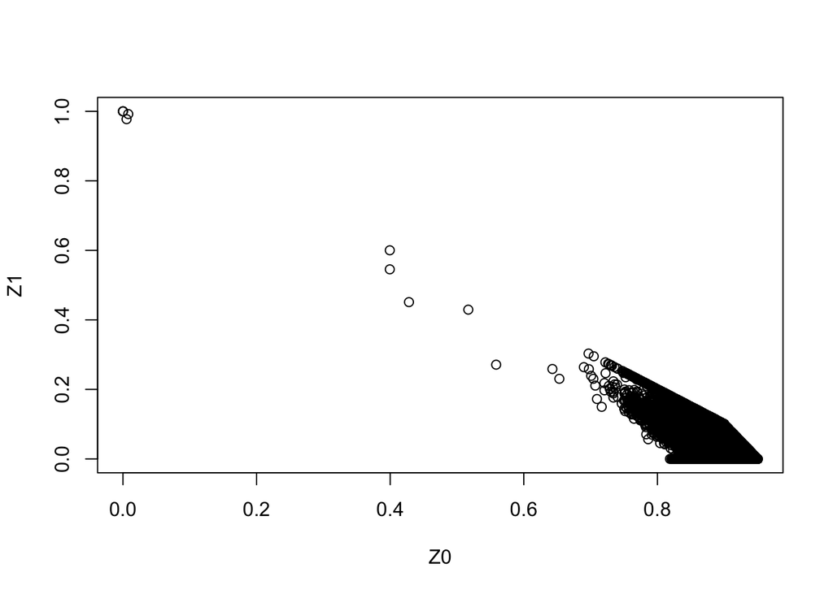

```r
z0 = genotypes.08.genome$Z0
z1 = genotypes.08.genome$Z1
plot(z0, z1, xlab = "Z0", ylab = "Z1")
```

The plot reveals first-degree relatives that need to be removed (one individual from each pair) because some downstream calculations (like PCA) are sensitive to them!

```bash
plink2 --bfile genotypes.07 --remove samples_to_exclude.txt --make-bed --out genotypes.09
```

### Exclude samples with high heterozigosity

Split the dataset into EUR and AFR ancestry subsets and, for each subset separately, calculate statistics to identify samples with high heterozigosity (e.g., due to sample contamination or population outliers) for sample exclusion:

```bash
plink2 --bfile genotypes.09 --filter phenotypes.txt EUR --mfilter 6 --het --out genotypes.10.EUR
plink2 --bfile genotypes.09 --filter phenotypes.txt AFR --mfilter 6 --het --out genotypes.10.AFR
```

These calculations are NOT LD-sensitive and therefore is usually a good idea to perform some form of LD-based pruning before invoking them!

```r
genotypes.10.EUR.het = read.table("genotypes.10.EUR.het", header = TRUE, check.names = FALSE, as.is = TRUE)
head(genotypes.10.EUR.het)
```

```
##       FID     IID O(HOM) E(HOM) N(NM)         F
## 1  GBR001 HG00155  26852  27410 38961 -0.047940
## 2  GBR002 HG00146  27201  27410 38961 -0.017740
## 3  GBR003 HG00158  27021  27410 38961 -0.033320
## 4 HG00096 HG00096  28104  27410 38961  0.060410
## 5 HG00097 HG00097  27169  27410 38961 -0.020510
## 6 HG00099 HG00099  27507  27410 38961  0.008741
```

For each sample:

- FID = Family ID
- IID = Within-family/Individual ID
- O(HOM) = Observed number of homozygotes
- E(HOM) = Expected number of homozygotes
- N(NM) = Number of non-missing autosomal genotypes
- F = Method-of-moments F coefficient estimate

Generate and inspect the F vs (sorted) samples plot to visually identify samples with high heterozigosity for sample exclusion:

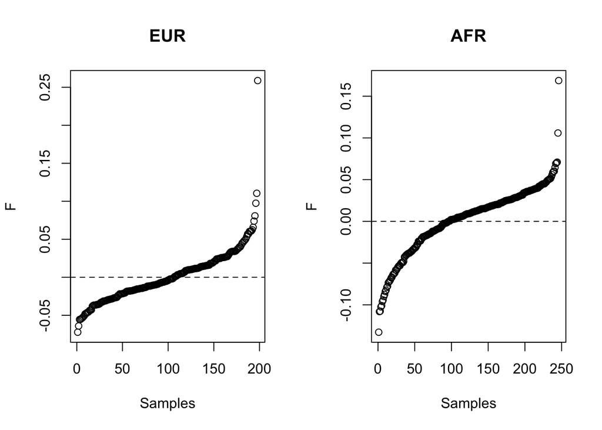

```r
par(mfrow = c(1,2))

genotypes.10.EUR.het = read.table("genotypes.10.EUR.het", header = TRUE, check.names = FALSE, as.is = TRUE)
plot(genotypes.10.EUR.het %>% arrange(F) %$% F, xlab = "Samples", ylab = "F", main = "EUR")
abline(h = 0, lty = 2)

genotypes.10.AFR.het = read.table("genotypes.10.AFR.het", header = TRUE, check.names = FALSE, as.is = TRUE)
plot(genotypes.10.AFR.het %>% arrange(F) %$% F, xlab = "Samples", ylab = "F", main = "AFR")
abline(h = 0, lty = 2)
```

```r
par(mfrow = c(1,1))
```

The plots reveal a couple of samples with high heterozigosity. Use an F-value threshold for sample exclusion and merge the two subsets:

```bash
plink2 --bfile genotypes.09 --remove samples_to_exclude.txt --make-bed --out genotypes.11.EUR
plink2 --bfile genotypes.09 --remove samples_to_exclude.txt --make-bed --out genotypes.11.AFR

plink2 --bfile genotypes.11.EUR --bmerge genotypes.11.AFR --make-bed --out genotypes.11
```

### Exclude population outliers or samples with ancestry discordance

Correct for population structure/stratification to avoid [confouding](https://en.wikipedia.org/wiki/Confounding) by population structure/stratification:

- http://www.ncbi.nlm.nih.gov/pubmed/3177389
- Stratify by self-reported ancestry (e.g., EUR vs AFR)
  - Good for large diffs between populations
  - Not so good for small diffs within populations
- Use genome-wide genotypes to correct for population sub-structure
  - [Principal components analysis](https://en.wikipedia.org/wiki/Principal_component_analysis) (PCA) is commonly used
  - PCA summarizes the variability in a dataset where each principal component is an independent linear combinations of the input variables, with the first component explaining the most variability, the second component explaining the second most, and so on.

Inspect the (PC3 vs) PC2 vs PC1 plot to visually identify population structure/sub-structure and incorporate the main principal components in the regression model to correct for population structure/stratification!

Unadjusted linear regression model:

$Y = \beta_G G + \epsilon$

Adjusted linear regression model:

$Y = \beta_G G + \beta_{PC1} PC1 + \beta_{PC2} PC2 + \beta_{PC3} PC3 + \epsilon$

Inspect the QQ-plot (observed vs expected P-values) of variant-trait associations to visually identify genomic inflation which is summarized by the genomic control lambda:

$\lambda_{GC} = median(\chi_{observed}^2)/median(\chi_{expected}^2) = median(\chi_{observed}^2)/0.4549364$

which should ideally be 1.00

See also: http://www.nature.com/ejhg/journal/v19/n7/full/ejhg201139a.html

#### Compare minor allele frequencies across different ancestry subsets/populations (e.g., EUR vs AFR)

Split the dataset into EUR and AFR ancestry subsets and calculate the minor allele frequencies for each subset separately:

```bash
plink2 --bfile genotypes.11 --filter phenotypes.txt EUR --mfilter 6 --freq --out genotypes.12.EUR
plink2 --bfile genotypes.11 --filter phenotypes.txt AFR --mfilter 6 --freq --out genotypes.12.AFR
```

```r
genotypes.12.EUR.frq = read.table("genotypes.12.EUR.frq", header = TRUE, check.names = FALSE, as.is = TRUE)
head(genotypes.12.EUR.frq)
```

```
##   CHR        SNP A1 A2      MAF NCHROBS
## 1  12  rs7954886  C  T 0.005076     394
## 2  12  rs4079417  A  C 0.002538     394
## 3  12 rs11063263  G  A 0.434000     394
## 4  12 rs10774263  G  A 0.426400     394
## 5  12 rs11614957  A  G 0.406100     394
## 6  12 rs12425974  G  C 0.446700     394
```

For each SNP:

- CHR = Chromosome code
- SNP = Variant identifier
- A1 = Allele 1 (usually minor)
- A2 = Allele 2 (usually major)
- MAF = Allele 1 frequency
- NCHROBS = Number of allele observations

```r
genotypes.12.EUR.frq = read.table("genotypes.12.EUR.frq", header = TRUE, check.names = FALSE, as.is = TRUE)
genotypes.12.AFR.frq = read.table("genotypes.12.AFR.frq", header = TRUE, check.names = FALSE, as.is = TRUE)

genotypes.12.merged.frq = merge(genotypes.12.EUR.frq, genotypes.12.AFR.frq, by = "SNP", suffixes = c(".EUR",".AFR"))

head(genotypes.12.merged.frq)
```

```
##         SNP CHR.EUR A1.EUR A2.EUR  MAF.EUR NCHROBS.EUR CHR.AFR A1.AFR
## 1 rs1000413      12      A      G 0.406100         394      12      A
## 2 rs1000499      12      T      C 0.154800         394      12      C
## 3 rs1000823      12      A      T 0.464500         394      12      T
## 4 rs1000824      12      G      A 0.233500         394      12      G
## 5 rs1001194      12      A      G 0.005076         394      12      A
## 6 rs1001408      12      C      T 0.083760         394      12      C
##   A2.AFR MAF.AFR NCHROBS.AFR
## 1      G 0.06707         492
## 2      T 0.47360         492
## 3      A 0.45330         492
## 4      A 0.40850         492
## 5      G 0.18500         492
## 6      T 0.03659         492
```

A1 is the minor allele and A2 is the major allele. However, what those alleles are depends on their frequencies in a specific ancestry subset/population and thus they can be swapped in different ancestry subsets/populations (e.g., EUR vs AFR)! Therefore, when comparing minor allele frequencies across ancestry subsets/populations, calculate MAF = 1-MAF for SNPs where the minor and major alleles are swapped, so that A1 and A2 refer to the same alleles across different ancestry subsets/populations.

```r
table(genotypes.12.merged.frq$A1.EUR != genotypes.12.merged.frq$A1.AFR)
```

```
##
## FALSE  TRUE
## 35860  6575
```

```r
genotypes.12.merged_and_corrected.frq = genotypes.12.merged.frq %>%
  sample_n(1000) %>%
  rowwise() %>%
  mutate(MAF.AFR = ifelse(A1.AFR != A1.EUR, 1-MAF.AFR, MAF.AFR)) %>%
  select(SNP, CHR.EUR, A1.EUR, A2.EUR, MAF.EUR, MAF.AFR) %>%
  rename(CHR = CHR.EUR, A1 = A1.EUR, A2 = A2.EUR)

head(genotypes.12.merged_and_corrected.frq)
```

```
## Source: local data frame [6 x 6]
##
##          SNP CHR A1 A2 MAF.EUR MAF.AFR
## 1 rs10845936  12  T  G  0.1269 0.11590
## 2  rs1995226  12  G  C  0.1015 0.08537
## 3   rs974799  12  T  C  0.1244 0.10370
## 4  rs3847814  12  T  C  0.1853 0.33940
## 5  rs1732290  12  A  G  0.1853 0.63010
## 6  rs1000499  12  T  C  0.1548 0.52640
```

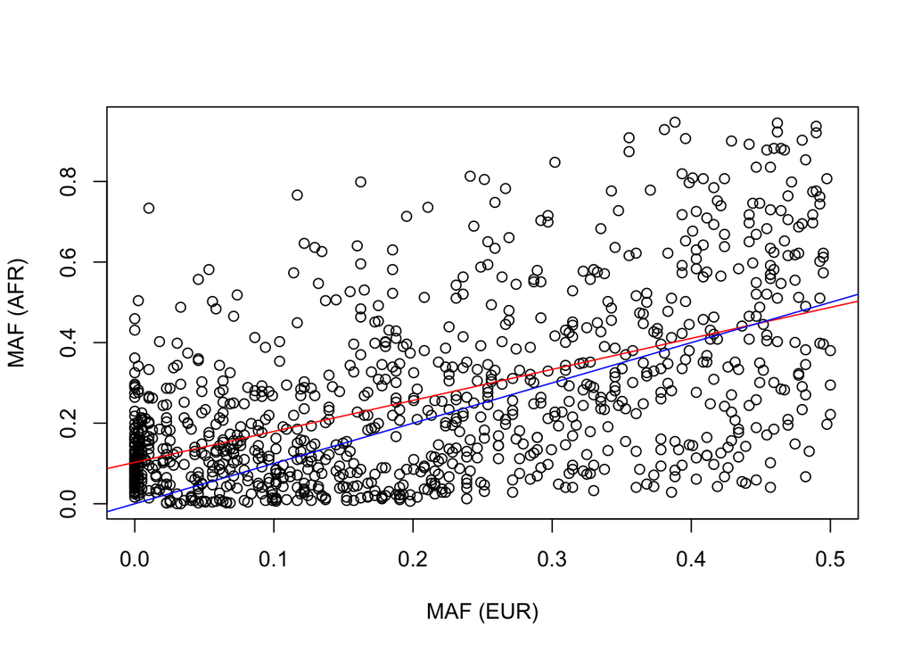

```r
x = genotypes.12.merged_and_corrected.frq$MAF.EUR
y = genotypes.12.merged_and_corrected.frq$MAF.AFR
plot(x, y, xlab = "MAF (EUR)", ylab = "MAF (AFR)")
abline(lm(y ~ x), col = "red")
abline(a = 0, b = 1, col = "blue")
```

The plot reveal that, while weakly correlated, minor allele frequencies are, as expected, different in the EUR and AFR ancestry subsets.

#### Correct for population structure/stratification using PCA

Calculate PCs using [EIGENSOFT](https://github.com/DReichLab/EIG) or [SNPRelate](http://www.bioconductor.org/packages/release/bioc/vignettes/SNPRelate/inst/doc/SNPRelateTutorial.html) and include in the phenotype file as covariates.

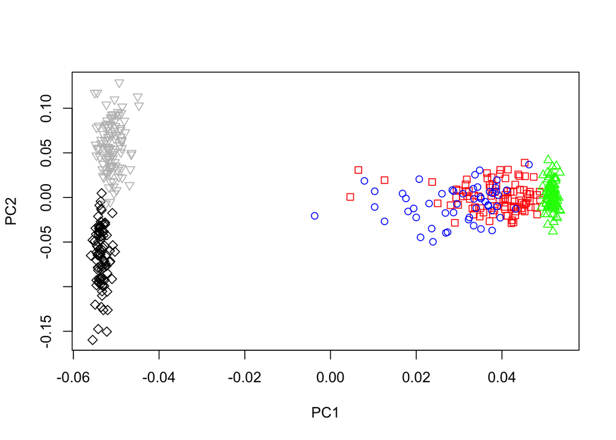

```r
# EUR
GBR = phenotypes$Population == "GBR"
IBS = phenotypes$Population == "IBS"

# AFR
ACB = phenotypes$Population == "ACB"
ASW = phenotypes$Population == "ASW"
ESN = phenotypes$Population == "ESN"

plot(phenotypes$PC1, phenotypes$PC2, xlab = "PC1", ylab = "PC2", type = "n")

points(phenotypes$PC1[GBR], phenotypes$PC2[GBR], col = "black", pch = 5)
points(phenotypes$PC1[IBS], phenotypes$PC2[IBS], col = "grey", pch = 6)
points(phenotypes$PC1[ACB], phenotypes$PC2[ACB], col = "red", pch = 0)
points(phenotypes$PC1[ASW], phenotypes$PC2[ASW], col = "blue", pch = 1)
points(phenotypes$PC1[ESN], phenotypes$PC2[ESN], col = "green", pch = 2)
```

## Univariate association analysis

Y1 in the phenotypes file is a continuous trait (e.g., weight, height, blood pressure, etc).

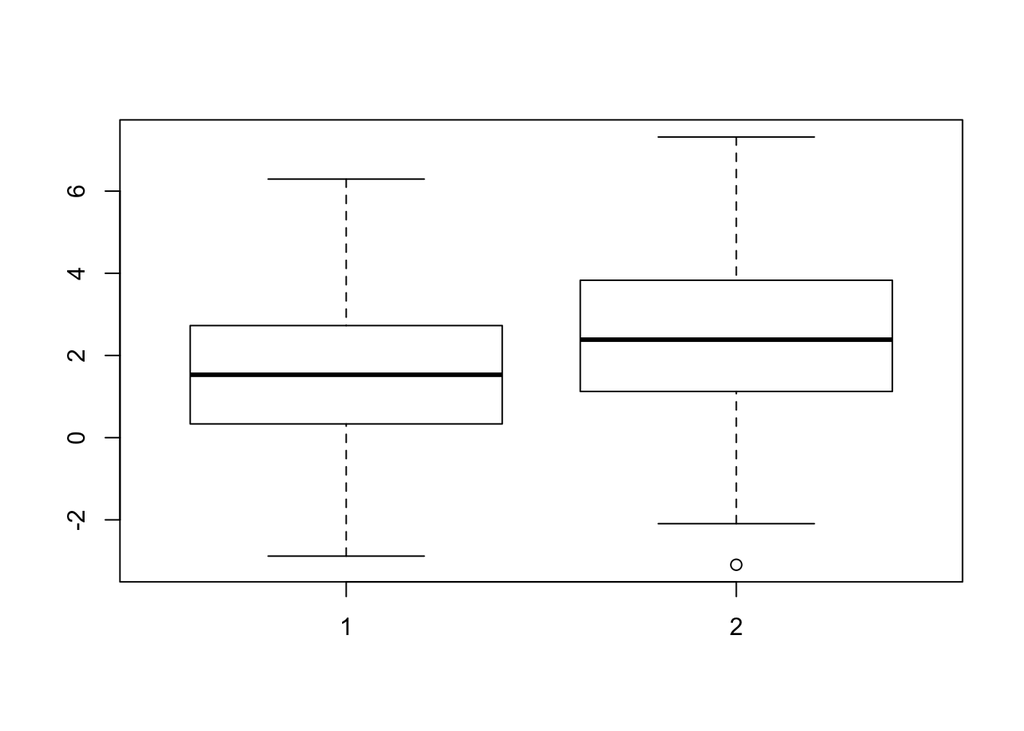

```r
boxplot(phenotypes$Y1 ~ phenotypes$Gender)
```

Linear regression is used to study the association between genotype and a continuos trait/phenotype (Y1):

$Y_1 = a + b_G Z(G) + b'X + \epsilon$

Z(G) is the coding of the genotype (A = major allele, B = minor allele):

| Model | Z(G=AA) | Z(G=AB) | Z(G=BB) | PLINK |
| --- | --- | --- | --- | --- |
| Additive | 0 | 1 | 2 | –add (default) |
| Dominant | 0 | 1 | 1 | –dominant |
| Recessive | 0 | 0 | 1 | –recessive |

It is important to report whether the major or the minor allele is used as the effect allele (PLINK uses the minor allele as the effect allele)!

### Unadjusted linear regression model

```bash
plink2 --bfile genotypes.11 --pheno phenotypes.txt --pheno-name Y1 --linear --ci 0.95 --out genotypes.13
```

```r
genotypes.13.assoc.linear = read.table("genotypes.13.assoc.linear", header = TRUE, as.is = TRUE)
head(genotypes.13.assoc.linear)
```

```
##   CHR        SNP     BP A1 TEST NMISS     BETA     SE     L95    U95
## 1  12  rs7954886 180185  C  ADD   444  0.01161 0.1831 -0.3473 0.3706
## 2  12  rs4079417 180472  A  ADD   444  0.04691 0.5114 -0.9555 1.0490
## 3  12 rs11063263 191619  G  ADD   444  0.03312 0.1227 -0.2073 0.2735
## 4  12 rs10774263 192220  G  ADD   444 -0.04531 0.1219 -0.2842 0.1936
## 5  12 rs11614957 195309  A  ADD   444  0.03337 0.1328 -0.2269 0.2936
## 6  12 rs12425974 196575  C  ADD   444  0.01605 0.1212 -0.2215 0.2536
##       STAT      P
## 1  0.06338 0.9495
## 2  0.09172 0.9270
## 3  0.27000 0.7873
## 4 -0.37180 0.7102
## 5  0.25130 0.8017
## 6  0.13250 0.8947
```

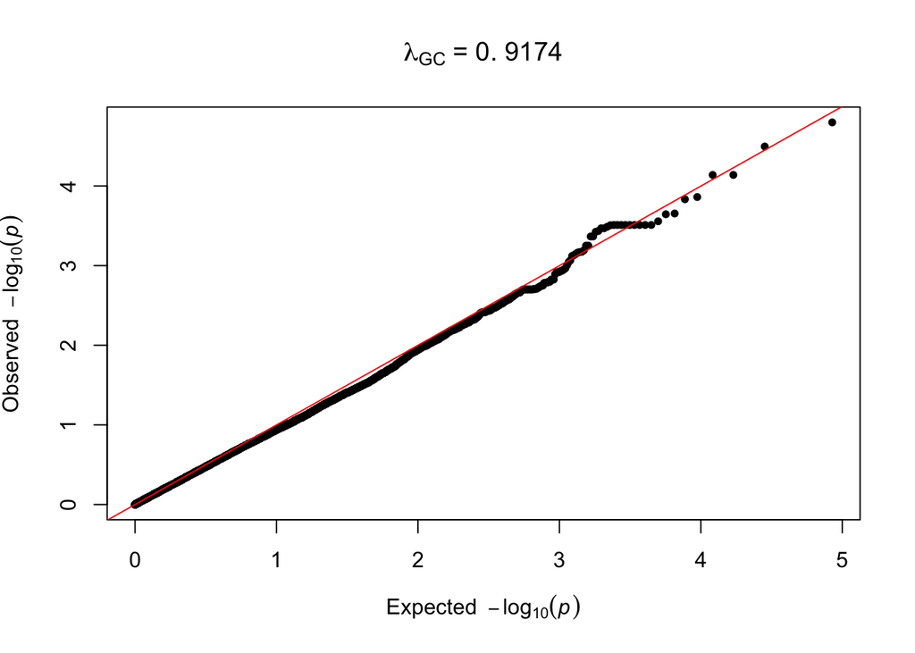

```r
pvals.unadjusted = genotypes.13.assoc.linear %>% filter(!is.na(P)) %>% arrange(P) %$% P
lambdagc.unadjusted = median(genotypes.13.assoc.linear$STAT^2, na.rm = TRUE)/qchisq(0.5, 1)
qq(pvals.unadjusted, main = latex2exp(paste0("$\\lambda_{GC}$ = ", round(lambdagc.unadjusted, 4))))
```

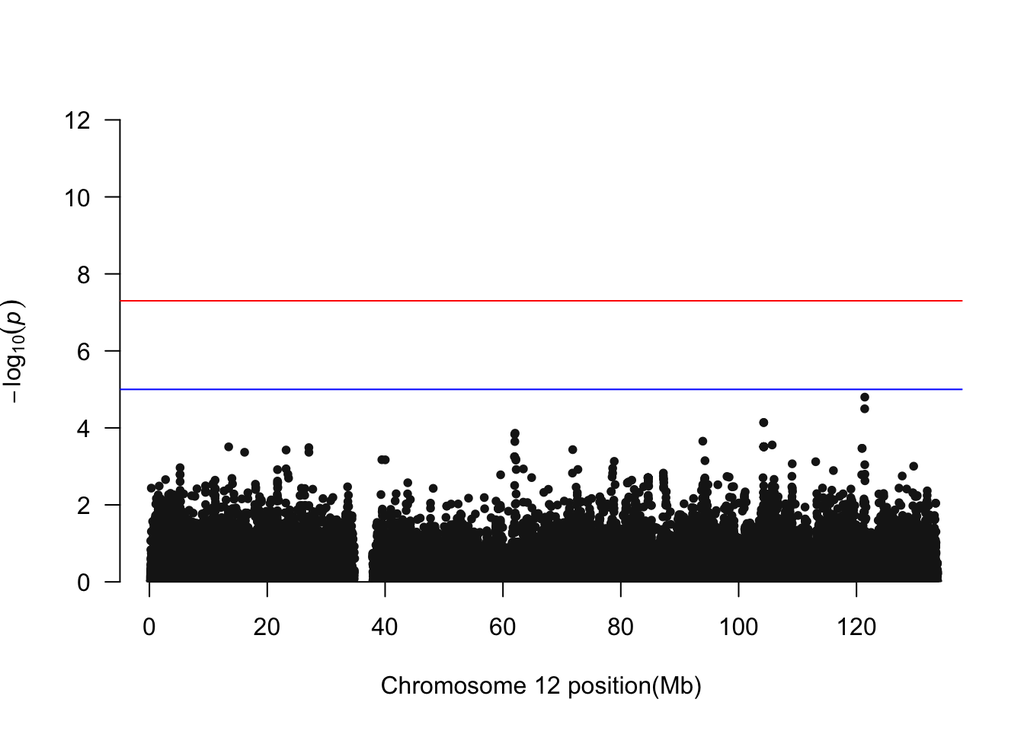

```r
manhattan(genotypes.13.assoc.linear, ylim = c(0, 12))
```

```r
genotypes.13.assoc.linear %>% filter(!is.na(P) & P <= 10e-6)
```

```
##  [1] CHR   SNP   BP    A1    TEST  NMISS BETA  SE    L95   U95   STAT
## [12] P
## <0 rows> (or 0-length row.names)
```

### Adjusted linear regression model

```bash
plink2 --bfile genotypes.11 --pheno phenotypes.txt --pheno-name Y1 --covar phenotypes.txt --covar-name Gender,PC1-PC3 --hide-covar --linear --ci 0.95 --out genotypes.14
```

```r
genotypes.14.assoc.linear = read.table("genotypes.14.assoc.linear", header = TRUE, as.is = TRUE)
head(genotypes.14.assoc.linear)
```

```
##   CHR        SNP     BP A1 TEST NMISS      BETA     SE     L95    U95
## 1  12  rs7954886 180185  C  ADD   444  0.058060 0.1937 -0.3216 0.4377
## 2  12  rs4079417 180472  A  ADD   444  0.138800 0.4931 -0.8277 1.1050
## 3  12 rs11063263 191619  G  ADD   444  0.006103 0.1185 -0.2262 0.2384
## 4  12 rs10774263 192220  G  ADD   444 -0.047350 0.1176 -0.2779 0.1832
## 5  12 rs11614957 195309  A  ADD   444  0.040220 0.1288 -0.2122 0.2926
## 6  12 rs12425974 196575  C  ADD   444 -0.031900 0.1436 -0.3133 0.2495
##       STAT      P
## 1  0.29980 0.7645
## 2  0.28150 0.7785
## 3  0.05148 0.9590
## 4 -0.40260 0.6874
## 5  0.31240 0.7549
## 6 -0.22220 0.8243
```

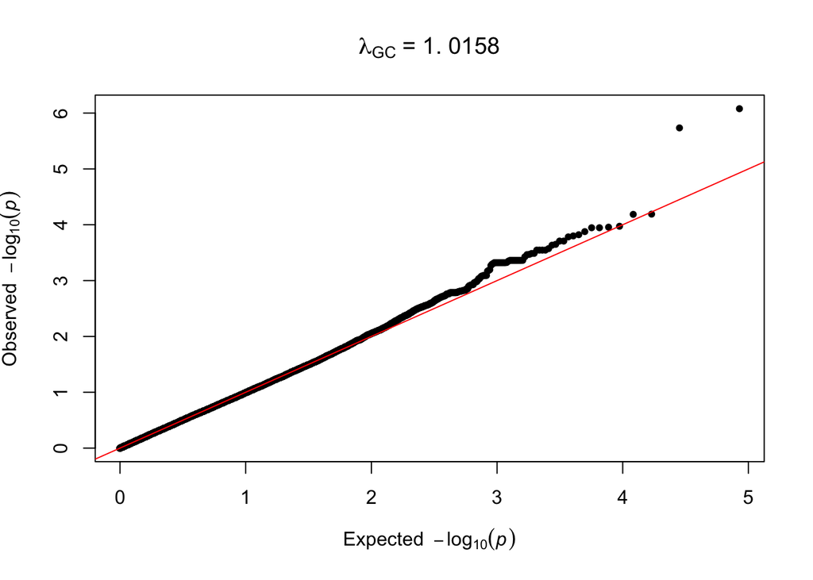

```r
pvals.adjusted = genotypes.14.assoc.linear %>% filter(!is.na(P)) %>% arrange(P) %$% P
lambdagc.adjusted = median(genotypes.14.assoc.linear$STAT^2, na.rm = TRUE)/qchisq(0.5, 1)
qq(pvals.adjusted, main = latex2exp(paste0("$\\lambda_{GC}$ = ", round(lambdagc.adjusted, 4))))
```

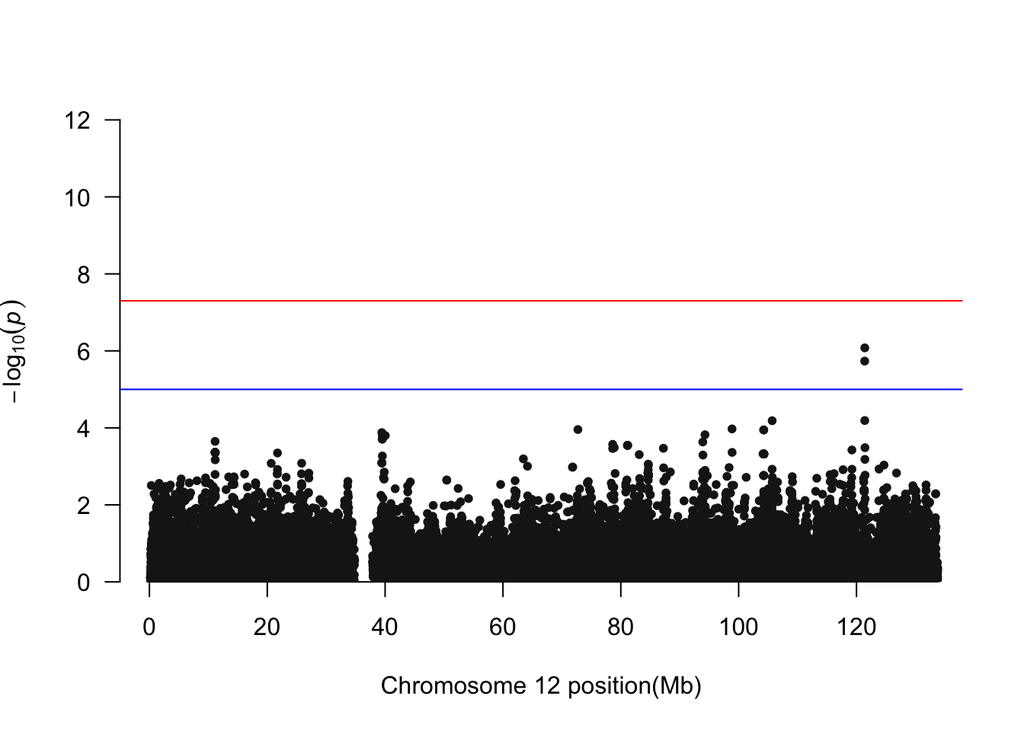

```r
manhattan(genotypes.14.assoc.linear, ylim = c(0, 12))
```

```r
genotypes.14.assoc.linear %>% filter(!is.na(P) & P <= 10e-6)
```

```
##   CHR       SNP        BP A1 TEST NMISS   BETA     SE    L95   U95  STAT
## 1  12 rs2650000 121388962  A  ADD   444 0.7905 0.1635 0.4701 1.111 4.835
## 2  12 rs2251468 121405126  C  ADD   444 0.8209 0.1642 0.4991 1.143 4.999
##              P
## 1 0.0000018430
## 2 0.0000008343
```

[Logistic regression is used to study the association between genotype and a binary trait/phenotype (AFF/UNAFF)]

Covariate adjustment is useful to eliminate confounding due to population structure. It can also increase power when adjusting for non-confounding variables (e.g., gender). But be careful, whether adjusting for a variable associated with Y1 makes sense depends on the study design, analysis type and the underlying causal model!

- http://www.ncbi.nlm.nih.gov/pubmed/25640676
- http://www.ncbi.nlm.nih.gov/pubmed/22820511
- http://www.ncbi.nlm.nih.gov/pubmed/23162385
- http://www.ncbi.nlm.nih.gov/pubmed/20025064

## Genotype imputation

The goal of imputation is to infer genotypes at untyped markers and it is necessary for cross-chip comparisons (e.g., Illumina and Affymetrix GWAS chips).

Two widely used methods for imputation are:

- MaCH/Minimac
  - http://genome.sph.umich.edu/wiki/MaCH
  - http://genome.sph.umich.edu/wiki/Minimac3
  - http://genome.sph.umich.edu/wiki/Minimac3_Imputation_Cookbook
- Impute/Impute2
  - https://mathgen.stats.ox.ac.uk/impute/impute.html
  - https://mathgen.stats.ox.ac.uk/impute/impute_v2.html
  - http://genome.sph.umich.edu/wiki/IMPUTE2:_1000_Genomes_Imputation_Cookbook

## GWAS meta-analysis

Meta-analysis is necessary because individual studies are often underpowered and it is impractical to share sample-level data

- http://www.ncbi.nlm.nih.gov/pubmed/24762786

Fixed-effect meta-analysis is widely used for GWAS (the classical random-effect meta-analysis is not suitable for GWAS) but alternatives that are more powerful in the presence of effect heterogeneity are also available:

- METASOFT
  - http://genetics.cs.ucla.edu/meta/
  - http://www.buhmhan.com/research
  - http://zarlab.cs.ucla.edu/heterogeneity-and-meta-analysis/
  - http://www.cell.com/ajhg/abstract/S0002-9297(14)00071-8

Meta-analysis is not difficult, but it is difficult to keep track of SNPs across studies due to the fact that often different studies use a different effect allele for the same SNP!

- METAL - Meta-analysis Helper
  - http://genome.sph.umich.edu/wiki/METAL

## Multivariate association analysis - Geneset association tests

- Aggregate univariate test statistics
  - Sum the N largest chi-square associations statistics out of all SNPs that are located on/near genes that belong to a particular biological pathway (e.g., DNA repair genes for cancer)
    - `plink --set-test`
- Multivariate models
  - Likelihood ratio statistic, Hotelling’s T
  - Kernel machine regression, e.g., [SKAT](http://www.hsph.harvard.edu/skat/)
  - When testing the association between a trait and a single imputed SNP we are essentially testing the association between the trait and a weighted average of multiple genotyped SNPs, where the weights are determined by the imputation reference panel